# 4. Greedy Algorithms II

Algorithm II

4. Greedy Algorithms II

WU Xiaokun 吴晓堃

xkun.wu [at] gmail

2021/10/22

# Dijkstra′s algorithm

## Single-pair shortest path problem

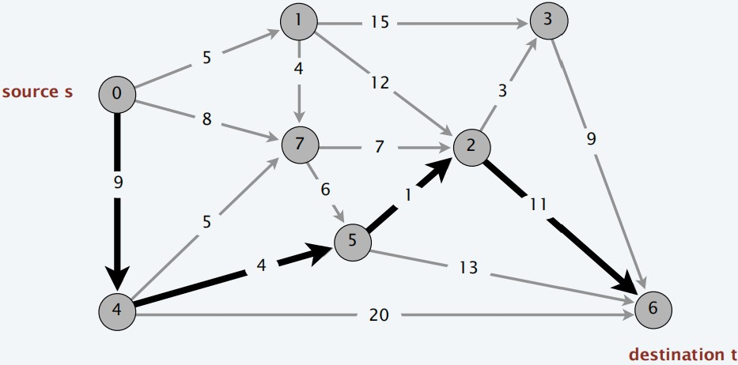

## Single-source shortest paths problem

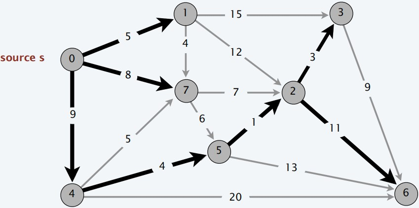

## Dijkstra′s (single-source shortest-paths)

**Greedy approach**. Maintain a set of explored nodes $S$ for which algorithm has determined $d[u]$ = length of a shortest $s \leadsto u$ path.

- Initialize $S = \{ s \}$, $d[s] = 0$.
- Repeatedly choose unexplored node $v \notin S$ which minimizes $\pi(v) = \min_{e=(u,v): u \in S} d[u] + l_e$.
  - add $v$ to $S$, and set $d[v] = \pi(v)$.
- To recover path, set $pred[v]$ = $e$ that achieves `min`.

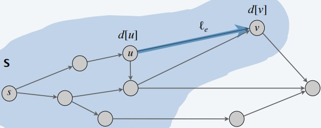

## Dijkstra′s: proof of correctness

$|S| = 1$ is clear: $S = \{ s \}$, $d[s] = 0$; now assume true for $|S| \ge 1$.

- Let $v$ be next node added to $S$, and let $(u, v)$ be the last edge.
  - A shortest $s \leadsto u$ path plus $(u, v)$ is an $s \leadsto v$ path of length $\pi(v)$.
- Consider any other $s \leadsto v$ path $P$: show it’s no shorter than $\pi(v)$.
  - Let $e = (x, y) \in P$ leaves $S$ first; $Pʹ$ the subpath $s \leadsto x$.
  - Length of $P$ is already $\ge \pi(v)$ when reaches $y$:
    - $l(P) \ge l(P') + l_e \ge d[x] + l_e \ge \pi(y) \ge \pi(v)$.

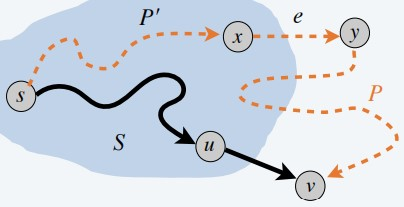

## Dijkstra′s: efficient implementation

**Critical optimization 1**. For each unexplored node $v \notin S$: explicitly maintain $\pi[v]$ instead of computing directly from definition $\pi(v) = \min_{e=(u,v): u \in S} d[u] + l_e$

- For each $v \notin S$: $\pi(v)$ can only decrease (because set $S$ increases).
- More specifically, suppose $u$ is added to $S$ and there is an edge $e = (u, v)$ leaving u.
  - Then, it suffices to update: $\pi(v) = \min\{\pi(v), \pi(u) + l_e\}$.

**Critical optimization 2**. Use a *min-oriented priority queue (PQ)* to choose an unexplored node that minimizes $\pi[v]$.

**Implementation**.

- Algorithm maintains $\pi[v]$ for each node $v$.
- Priority queue stores unexplored nodes, using $\pi[\cdot]$ as priorities.
- Once $u$ is deleted from the `PQ`, $\pi[u]$ = length of a shortest $s \leadsto u$ path.

## Dijkstra′s: algorithm

1. FOREACH $v \ne s$: $\pi[v] = \infty$, $pred[v]$ = `null`; $\pi[s] = 0$;
2. Create an empty priority queue `pq`;
3. FOREACH $v \in V$ : `INSERT`(`pq`, $v$, $\pi[v]$);
4. WHILE (IS-NOT-EMPTY(`pq`)):
   1. $u$ = `DEL-MIN`(`pq`);
   2. FOREACH edge $e = (u, v) \in E$ leaving $u$:
      1. IF $(\pi[v] \le \pi[u] + l_e)$: CONTINUE;
      2. `DECREASE-KEY`(`pq`, $v$, $\pi[u] + l_e$);
      3. $\pi[v] = \pi[u] + l_e$;
      4. $pred[v] = e$;

## Demo: Dijkstra′s algorithm

## Dijkstra′s: analysis

**Performance**. Depends on `PQ`: $n$ `INSERT`, $n$ `DELETE-MIN`, $\le m$ `DECREASE-KEY`.

- each priority queue operation can be made to run in $O(\log n)$ time.
- overall time for the implementation is $O(m \log n)$.

## Dijkstra′s: which priority queue?

**Performance**. Depends on `PQ`: $n$ `INSERT`, $n$ `DELETE-MIN`, $\le m$ `DECREASE-KEY`.

- Array implementation optimal for dense graphs ($\Theta(n^2)$ edges).
- Binary heap much faster for sparse graphs ($\Theta(n)$ edges).
- 4-way heap worth the trouble in performance-critical situations.

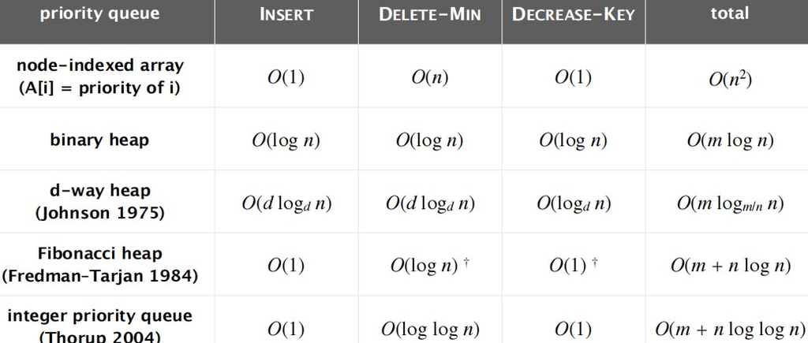

## Quiz: single-source shortest-paths

How to solve the the single-source shortest paths problem in *undirected* graphs with positive edge lengths?

**A.** Replace each undirected edge with two antiparallel edges of same length. Run Dijkstra’s algorithm in the resulting digraph.

**B.** Modify Dijkstra’s algorithms so that when it processes node u, it consider all edges incident to u (instead of edges leaving u).

**C.** Either A or B.

**D.** Neither A nor B.

- A is standard treatment.
- B also works.

## Undirected single-source shortest paths

**Theorem**. [Thorup 1999] Can solve single-source shortest paths problem in undirected graphs with positive integer edge lengths in $O(m)$ time.

**Remark**. Does not explore nodes in increasing order of distance from s.

## Dijkstra′s: extensions

Dijkstra’s algorithm and proof extend to several related problems:

- Shortest paths in undirected graphs: $\pi[v] \le \pi[u] + l(u, v)$.
- Maximum capacity paths: $\pi[v] \ge min \{ \pi[u], c(u, v) \}$.
- Maximum reliability paths: $\pi[v] \ge \pi[u] \times \gamma(u, v)$

# Minimum Spanning Tree

## Cycles

**Def**. A **path** is a sequence of edges which connects a sequence of nodes.

**Def**. A **cycle** is a path with no repeated nodes or edges other than the starting and ending nodes.

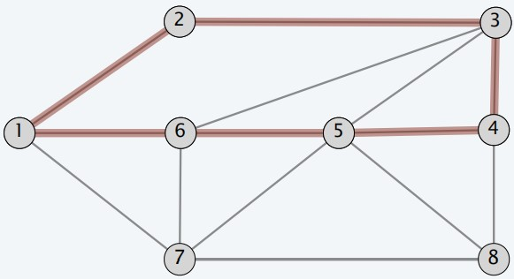

- path P = { (1, 2), (2, 3), (3, 4), (4, 5), (5, 6) }
- cycle C = { (1, 2), (2, 3), (3, 4), (4, 5), (5, 6), (6, 1) }

## Cuts

**Def**. A **cut** is a partition of the nodes into two nonempty subsets $S$ and $V – S$.

**Def**. The **cutset** of a cut $S$ is the set of edges with exactly one endpoint in $S$.

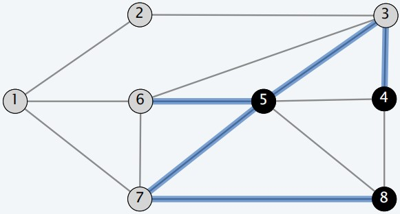

- cut S = { 4, 5, 8 }
- cutset D = { (3, 4), (3, 5), (5, 6), (5, 7), (8, 7) }

## Quiz: Cutset

Let C be a cycle and let D be a cutset. How many edges do C and D have in common? Choose the best answer.

- 0
- 2
- not 1
- an even number

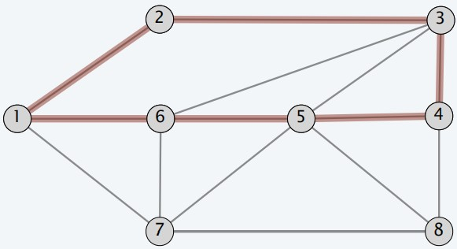

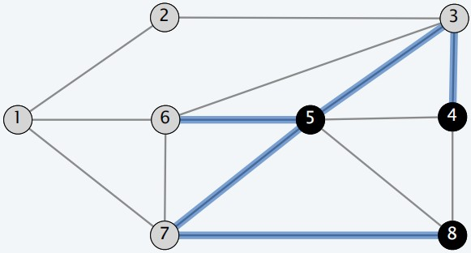

Hint: cycle cross the cut, so even number of times

## Cycle–cut intersection

**Proposition**. A cycle and a cutset intersect in an even number of edges.

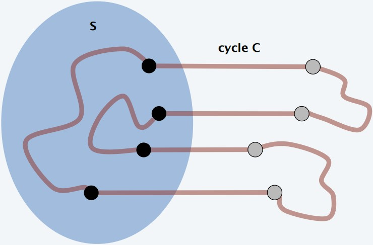

## Spanning tree

**Def**. Let $H = (V, T)$ be a subgraph of an undirected graph $G = (V, E)$. $H$ is a spanning tree of $G$ if $H$ is both *acyclic* and *connected*.

- the minimum effort to connect vertices topologically

## Quiz: spanning tree

Which of the following properties are true for all spanning trees H?

- Contains exactly $|V| – 1$ edges.
- The removal of any edge disconnects it.
- The addition of any edge creates a cycle.
- All of the above.

## Spanning tree: properties

**Proposition**. Let $H = (V, T)$ be a subgraph of an undirected graph $G = (V, E)$.

Then, the following are equivalent:

- $H$ is a spanning tree of $G$.
- $H$ is acyclic and connected.
- $H$ is connected and has $|V| - 1$ edges.
- $H$ is acyclic and has $|V| - 1$ edges.
- $H$ is minimally connected: removal of any edge disconnects it.
- $H$ is maximally acyclic: addition of any edge creates a cycle.

## Minimum spanning tree (MST)

**Def**. Given a connected, undirected graph $G = (V, E)$ with edge costs $c_e$, a **minimum spanning tree** $(V, T)$ is a spanning tree of $G$ such that the sum of the edge costs in $T$ is minimized.

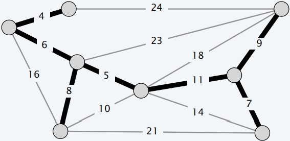

**Cayley’s theorem**. The complete graph on $n$ nodes has $n^{n–2}$ spanning trees.

- can’t solve by brute-force

## Fundamental cycle

**Fundamental cycle**. Let $H = (V, T)$ be a spanning tree of $G = (V, E)$.

- For any non tree-edge $e \in E : T \cup \{ e \}$ contains a unique cycle, say C.
- For any edge $f \in C : (V, T \cup \{ e \} – \{ f \})$ is a spanning tree.

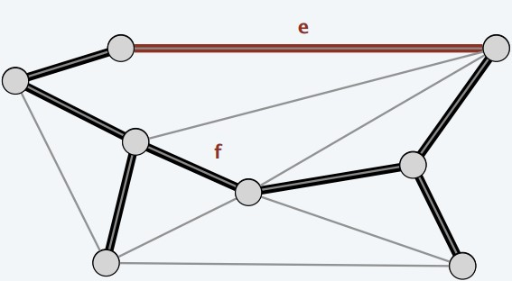

**Observation**. If $c_e < c_f$, then $(V, T)$ is not an MST.

## Fundamental cutset

**Fundamental cutset**. Let $H = (V, T)$ be a spanning tree of $G = (V, E)$.

- For any tree edge $f \in T : (V, T – \{ f \})$ has two connected components.
  - Let $D$ denote corresponding cutset.
- For any edge $e \in D : (V, T – { f } \cup { e })$ is a spanning tree.

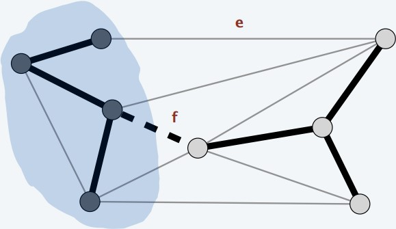

**Observation**. If $c_e < c_f$, then $(V, T)$ is not an MST.

## MST: greedy coloring

**Red rule**.

- Let $C$ be a cycle with no red edges.
- Select an uncolored edge of $C$ of *max cost* and color it red.

**Blue rule**.

- Let $D$ be a cutset with no blue edges.
- Select an uncolored edge in $D$ of *min cost* and color it blue.

**Greedy coloring**.

- Apply the red and blue rules (non-deterministically!) until all edges are colored. The blue edges form an MST.
- Note: can stop once $n – 1$ edges colored blue.

## Greedy coloring: invariant

**Color invariant**. There exists an $MST (V, T^\ast)$ containing every blue edge and no red edge.  
**Pf**. Induction step (**blue rule**).

Suppose color invariant true before blue rule.

- Let $D$ be chosen cutset, and let $f$ be edge colored blue.
- if $f \in T^\ast$, then $T^\ast$ still satisfies invariant.
- Otherwise, consider fundamental cycle $C$ by adding $f$ to $T^\ast$.
  - let $e \in C$ be another edge in $D$.
  - $e$ is uncolored and $c_e \ge c_f$ since:
    - $e \in T^\ast \Rightarrow e$ not red
    - blue rule $\Rightarrow e$ not blue and $c_e \ge c_f$
  - Thus, $T^\ast \cup \{ f \} – \{ e \}$ satisfies invariant.

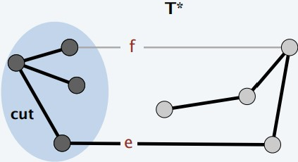

## Greedy coloring: invariant (cont.)

**Color invariant**. There exists an $MST (V, T^\ast)$ containing every blue edge and no red edge.  
**Pf**. Induction step (**red rule**).

Suppose color invariant true before red rule.

- Let $C$ be chosen cycle, and let $e$ be edge colored red.
- if $e \notin T^\ast$, then $T^\ast$ still satisfies invariant.
- Otherwise, consider fundamental cutset $D$ by deleting $e$ from $T^\ast$.
  - let $f \in D$ be another edge in $C$.
  - $f$ is uncolored and $c_e \ge c_f$ since:
    - $f \notin T^\ast \Rightarrow f$ not blue
    - red rule $\Rightarrow f$ not red and $c_e \ge c_f$
- Thus, $T^\ast \cup \{ f \} – \{ e \}$ satisfies invariant.

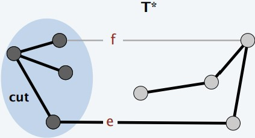

## Greedy coloring: correctness

**Theorem**. The greedy coloring algorithm terminates. Blue edges form an MST.  
**Pf**. show that either red or blue rule (or both) applies in each step.

Blue edges keep growing until forming a forest.

- Suppose edge $e$ is left uncolored.
- Case 1: both endpoints of $e$ are in same blue tree.
  - apply red rule to cycle formed by adding $e$ to blue forest.

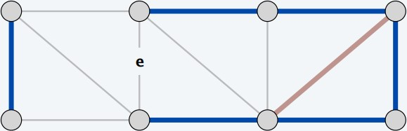

## Greedy coloring: correctness (cont.)

**Theorem**. The greedy coloring algorithm terminates. Blue edges form an MST.  
**Pf**. show that either red or blue rule (or both) applies in each step.

Blue edges keep growing until forming a forest.

- Suppose edge $e$ is left uncolored.
- Case 1: both endpoints of $e$ are in same blue tree.
  - apply red rule to cycle formed by adding $e$ to blue forest.
- Case 2: endpoints of $e$ are in different blue trees.
  - apply blue rule to cutset induced by either of two blue trees.

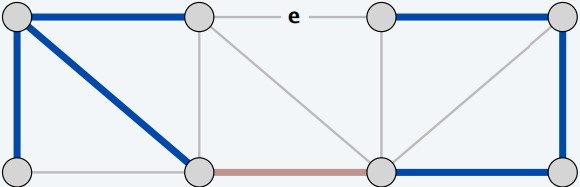

# Prim, Kruskal, Boruvka

## Prim′s algorithm

Initialize $S = \{ s \}$ for any node $s$, $T = \emptyset$.  
Repeat $n – 1$ times:

- Add to $T$ a min-cost edge with exactly one endpoint in $S$.
- Add the other endpoint to $S$.

**Theorem**. Prim’s algorithm computes an MST.  
**Pf**. Special case of greedy coloring (blue rule repeatedly applied to $S$).

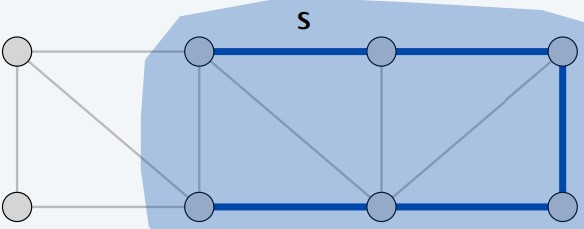

## Prim′s algorithm: implementation

1. $S = \emptyset, T = \emptyset$;
2. $s$ = any node in $V$;
3. FOREACH $v \ne s$: $\pi[v] = \infty$, $pred[v]$ = `null`; $\pi[s] = 0$;
4. Create an empty priority queue `pq`;
5. FOREACH $v \in V$: `INSERT`(`pq`, $v$, $\pi[v]$);
6. WHILE (IS-NOT-EMPTY(`pq`)):
   1. $u$ = `DEL-MIN`(`pq`);
   2. $S = S \cup { u }$, $T = T \cup \{ pred[u] \}$;
   3. FOREACH edge $e = (u, v) \in E$ with $v \notin S$:
      1. IF ($c_e \ge \pi[v]$): CONTINUE;
      2. `DECREASE-KEY`(`pq`, $v$, $c_e$);
      3. $\pi[v] = ce$; $pred[v] = e$;

## Prim′s algorithm: analysis

**Theorem**. Prim’s algorithm can be implemented to run in $O(m \log n)$ time.  
**Pf**. Implementation almost identical to Dijkstra’s algorithm.

Depends on `PQ`

- $n$ `INSERT`,
- $n$ `DELETE-MIN`,
- $\le m$ `DECREASE-KEY`.

## Kruskal′s algorithm

Consider edges in *ascending* order of cost:

- Add to tree unless it would create a cycle.

**Theorem**. Kruskal’s algorithm computes an MST.  
**Pf**. Special case of greedy coloring.

- Case 1: both endpoints of $e$ in same blue tree.
  - color $e$ red by applying red rule to unique cycle.
- Case 2: endpoints of e in different blue trees.
  - color $e$ blue by applying blue rule to cutset defined by either tree.

## Union-Find data structure

Pointer-based implementation

## Kruskal′s algorithm: implementation

1. SORT $m$ edges by cost and renumber so that $c(e_1) \le c(e_2) \le \ldots \le c(e_m)$;
2. $T = \emptyset$;
3. FOREACH $v \in V$: `MAKE-SET`(v);
4. FOR $i = 1 .. m$:
   1. $(u, v) = e_i$;
   2. IF (`FIND-SET`($u$) $\ne$ `FIND-SET`($v$)):
      1. $T = T \cup { e_i }$;
      2. `UNION`(u, v);
5. RETURN T.

## Kruskal′s algorithm: analysis

**Theorem**. Kruskal’s algorithm can be implemented to run in $O(m \log m)$ time.  
**Pf**.

- Sort edges by cost.
- Use `union–find` data structure to dynamically maintain connected components.

## Reverse-delete algorithm

Consider edges in *descending* order of cost:

- Start with all edges in $T$.
- Delete edge from $T$ unless it would disconnect $T$.

**Theorem**. The reverse-delete algorithm computes an MST.  
**Pf**. Special case of greedy coloring.

- Case 1. [ deleting edge $e$ does not disconnect $T$ ]
  - apply red rule to cycle $C$ formed by adding $e$ to another path in $T$ between its two endpoints
- Case 2. [ deleting edge $e$ disconnects $T$ ]
  - apply blue rule to cutset $D$ induced by either component

**Fact**. [Thorup 2000] Can be implemented to run in $O(m \log n (\log \log n)^3)$ time.

## Review: greedy MST algorithms

**Red rule**.

- Let $C$ be a cycle with no red edges.
- Select an uncolored edge of $C$ of *max cost* and color it red.

**Blue rule**.

- Let $D$ be a cutset with no blue edges.
- Select an uncolored edge in $D$ of *min cost* and color it blue.

**Greedy coloring**.

- Apply the red and blue rules (non-deterministically!) until all edges are colored. The blue edges form an MST.
- Note: can stop once $n – 1$ edges colored blue.

**Theorem**. The greedy algorithm is correct.

**Special cases**. Prim, Kruskal, reverse-delete

## Borůvka′s algorithm

Repeat until only one tree.

- Apply blue rule to cutset corresponding to *each* blue tree.
- Color *all* selected edges blue.

**Theorem**. Borůvka’s algorithm computes the MST.  
**Pf**. Special case of greedy coloring (repeatedly apply blue rule).

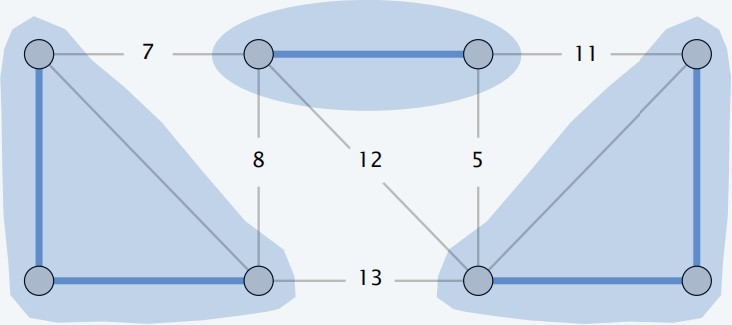

## Borůvka′s: analysis

**Theorem**. Borůvka’s algorithm can be implemented to run in $O(m \log n)$ time.  
**Pf**.

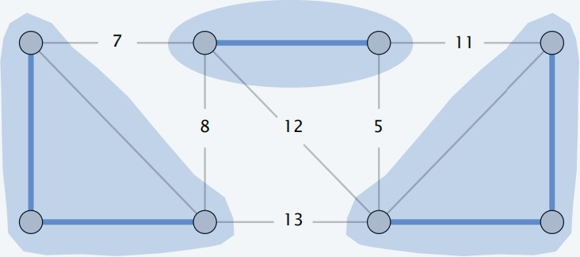

## Borůvka′s: Contraction implementation

**Contraction version**.

- After each phase, contract each blue tree to a single supernode.
- Delete self-loops and parallel edges (keeping only cheapest one).
- Borůvka phase becomes: take cheapest edge incident to each node.

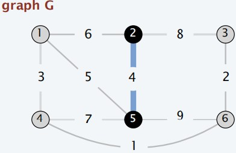

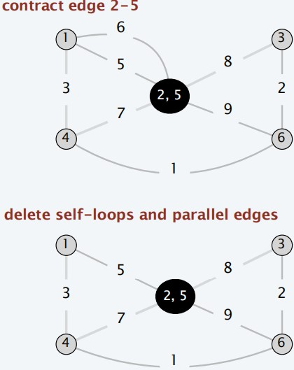

## Contract a set of edges

**Problem**. Given a graph $G = (V, E)$ and a set of edges $F$, contract all edges in $F$, removing any self-loops or parallel edges.

**Goal**. $O(m + n)$ time.

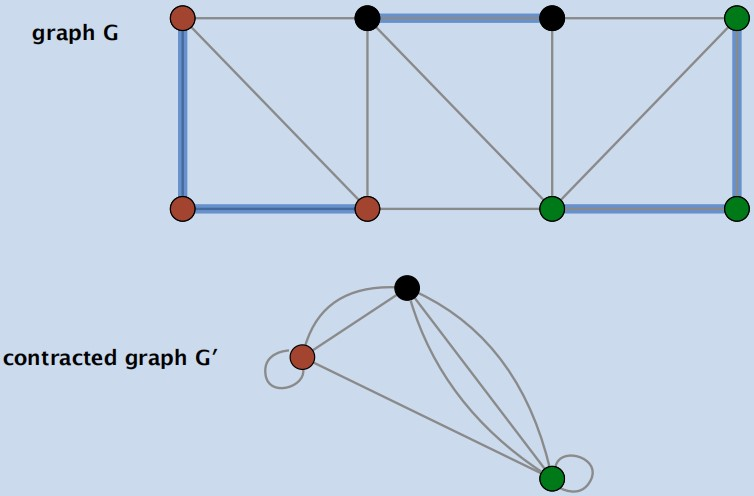

## Contract a set of edges: solution

**Problem**. Given a graph $G = (V, E)$ and a set of edges $F$, contract all edges in $F$, removing any self-loops or parallel edges.

**Solution**.

- Compute the $nʹ$ connected components in $(V, F)$.
- Suppose $id[u] = i$ means node $u$ is in connected component $i$.
- The contracted graph $Gʹ$ has $nʹ$ nodes.
- For each edge $u–v \in E$, add an edge $i–j$ to $Gʹ$, where $i = id[u]$ and $j = id[v]$.

Removing self loops: Easy.

Removing parallel edges.

- Create a list of edges $i–j$ with the convention that $i < j$.
- Sort the edges lexicographically via `LSD radix sort`.
- Add the edges to the graph $Gʹ$, removing parallel edges.

## Borůvka′s algorithm on planar graphs

**Theorem**. Borůvka’s algorithm (contraction version) can be implemented to run in $O(n)$ time on planar graphs.  
**Pf**.

- Each Borůvka phase takes $O(n)$ time:
  - Fact 1: $m \le 3n$ for simple planar graphs.
  - Fact 2: planar graphs remains planar after edge contractions/deletions.
- Number of nodes (at least) halves in each phase.
- Thus, overall running time $\le cn + cn / 2 + cn / 4 + cn / 8 + \ldots = O(n)$.

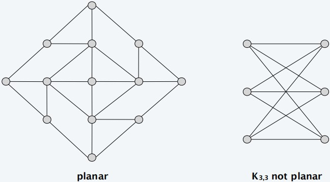

## Borůvka–Prim algorithm

**Borůvka–Prim algorithm**.

- Run Borůvka (contraction version) for $\log_2 \log_2 n$ phases.
- Run Prim on resulting, contracted graph.

**Theorem**. Borůvka–Prim computes an MST.  
**Pf**. Special case of the greedy algorithm.

**Theorem**. Borůvka–Prim can be implemented to run in $O(m \log \log n)$ time.  
**Pf**.

- The $\log_2 \log_2 n$ phases of Borůvka’s algorithm take $O(m \log \log n)$ time;
  - resulting graph has $\le n / \log_2 n$ nodes and $\le m$ edges.
- Prim’s algorithm (using Fibonacci heaps) takes $O(m + n)$ time on a graph with $n / \log_2 n$ nodes and $m$ edges.
  - precisely, $O(m + \frac{n}{\log n} \log (\frac{n}{\log n}))$.

# Single-link clustering

## Clustering

**Goal**. Given a set $U$ of $n$ objects labeled $p_1 .. p_n$, partition into clusters so that objects in different clusters are far apart.

[figure not shown]

## Clustering of maximum spacing

**$k$-clustering**. Divide objects into $k$ non-empty groups.

**Distance function**. Numeric value specifying “closeness” of two objects.

- $d(p_i , p_j) = 0$ iff $p_i = p_j$ [ identity ]
- $d(p_i, p_j) \ge 0$ [ non-negativity ]
- $d(p_i, p_j) = d(p_j, p_i)$ [ symmetry ]

**Spacing**. Min distance between any pair of points in different clusters.

**Goal**. Given an integer $k$, find a $k$-clustering of maximum spacing.

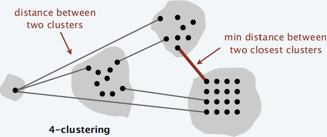

## Greedy clustering algorithm

“Well-known” algorithm in science literature for single-linkage k-clustering:

- Form a graph on the node set $U$, corresponding to $n$ clusters.
- Find the closest pair of objects such that each object is in a different cluster, and add an edge between them.
- Repeat $n – k$ times (until there are exactly $k$ clusters).

**Key observation**. This procedure is precisely Kruskal’s algorithm (except we stop when there are k connected components).

**Alternative**. Find an MST and delete the $k – 1$ longest edges.

## Greedy clustering: analysis

**Theorem**. Let $C^\ast = C^\ast_1, \ldots, C^\ast_k$ denote the clustering formed by deleting $k – 1$ longest edges of an MST. Then, $C^\ast$ is a k-clustering of max spacing.  
**Pf**.

Spacing of $C^\ast$ = length $d^\ast$ of the $(k – 1)^{st}$ longest edge in MST.

- Consider any other clustering $C = C_1, \ldots, C_k$.
  - need to show $C$ has a smaller spacing

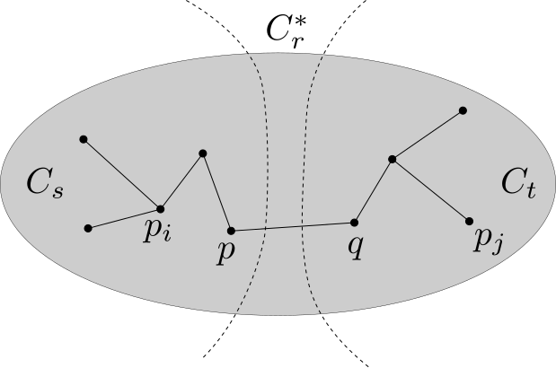

## Greedy clustering: analysis (cont.)

Let $p_i$ and $p_j$ be in the same cluster in $C^\ast$, say $C^\ast_r$, but different clusters in $C$, say $C_s$ and $C_t$.

- Some edge $(p, q)$ on $p_i – p_j$ path in $C^\ast_r$ spans two different clusters in $C$.
- Edge $(p, q)$ has length $\le d^\ast$ since it was added by Kruskal.
- Spacing of $C$ is $\le d^\ast$ since $p$ and $q$ are in different clusters.

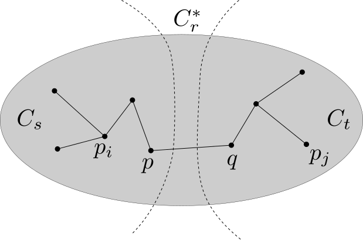